# Density Estimation

**Goal:** We are interested in estimation of a density function $f$ using observations of random variables $Y_1, \dots, Y_n$ sampled independently from $f$.

We will focus on **nonparametric** approaches to density estimation.

# 1 Histograms

One familiar density estimator is a histogram. Histograms are produced automatically by most software packages and are used so routinely to visualize densities that we rarely talk about their underlying complexity.

## 1.1 Motivation

Recall the definition of a density function
$$f(y) \equiv \frac{d}{dy} F(y) \equiv \lim\limits_{h \rightarrow 0} \frac{F(y + h) - F(y - h)}{2h} = \lim\limits_{h \rightarrow 0} \frac{F(y + h) - F(y)}{h},$$
where $F(x)$ is the cdf of the random variable $Y$.

Now, let $Y_1, \dots, Y_n$ be a random sample of size $n$ from the density $f$.

A natural finite-sample analog of $f(y)$ is to divide the support of $Y$ into a set of $K$ equi-sized bins with small width $h$ and replace $F(x)$ with the empirical cdf.

## 1.2 Bin Width

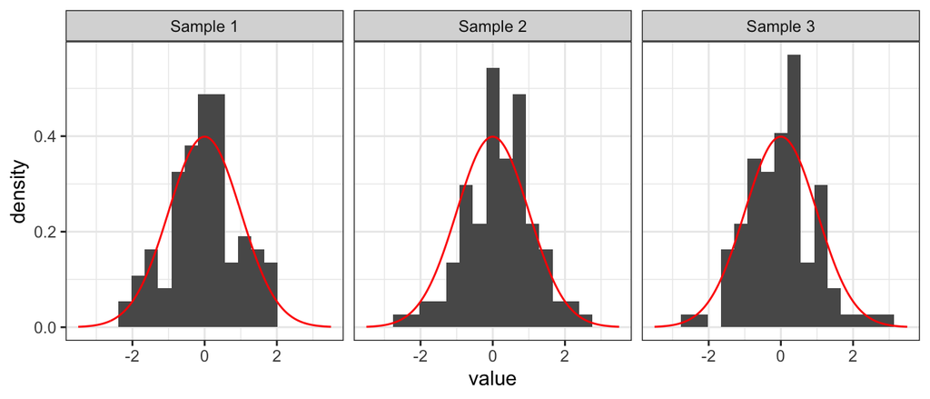

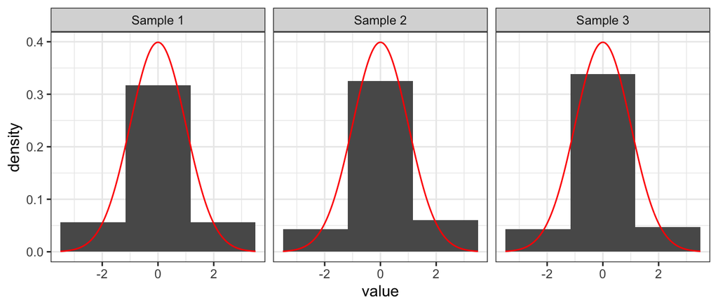

## 1.3 Measures of Performance

Squared Error

Mean Squared Error

Integrated Squared Error

Mean Integrated Squared Error

## 1.4 Optimal Binwidth

We will investigate bias and variance of $\hat f$ pointwise, because $\text{MSE}(y) = (\text{bias}(\hat f(y))^2 + \text{Var} \hat f(y)$.

The roughness of the underlying density, as measured by $R(f')$ determines the optimal level of smoothing and the accuracy of the histogram estimate.

We cannot find the optimal binwidth without known the density $f$ itself.

Simple (plug-in) approach: Assume $f$ is a $N(\mu, \sigma^2)$, then

Data driven approach:

# 2 Frequency Polygon

The histogram is simple, useful and piecewise constant.

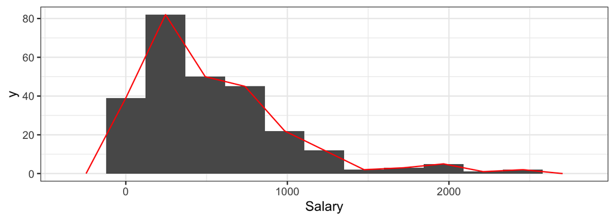

```r
library(ISLR)

# optimal h based on normal method
h_0 <- 3.491 * sd(Hitters$Salary, na.rm = TRUE) * sum(!is.na(Hitters$Salary))^(-1/3)

## original histogram with optimal h
ggplot(Hitters) +
  geom_histogram(aes(Salary), binwidth = h_0) -> p

## get values to build freq polygon
vals <- ggplot_build(p)$data[[1]]
poly_dat <- data.frame(x = c(vals$x[1] - h_0,
                             vals$x, vals$x[nrow(vals)] + h_0),
                       y = c(0, vals$y, 0))

## plot freq polygon
p + geom_line(aes(x, y), data = poly_dat, colour = "red")
```

Let $b_1, \dots, b_{K + 1}$ represent bin edges of bins with width $h$ and $n_1, \dots, n_K$ be the number of observations falling into the bins. Let $c_0, \dots, c_{k + 1}$ be the midpoints of the bin interval.

The frequency polygon is defined as

MISE

AMISE

Gaussian rule for binwidth

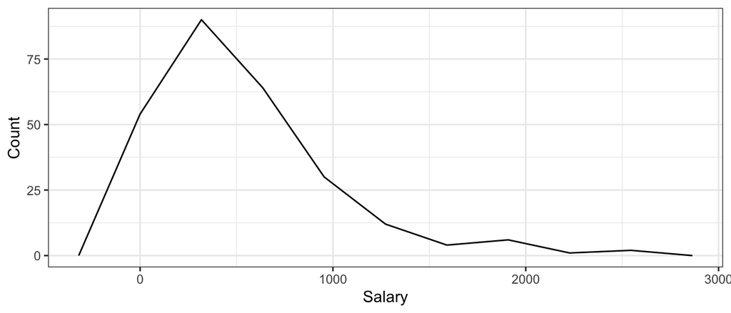

In practice, a simple way to construct locally varying binwidth histograms is by transforming the data to a different scale and then smoothing the transformed data. The final estimate is formed by simply transforming the constructed bin edges $\{b_j\}$ back to the original scale.

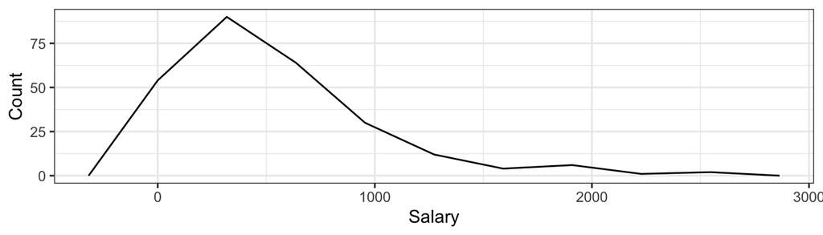

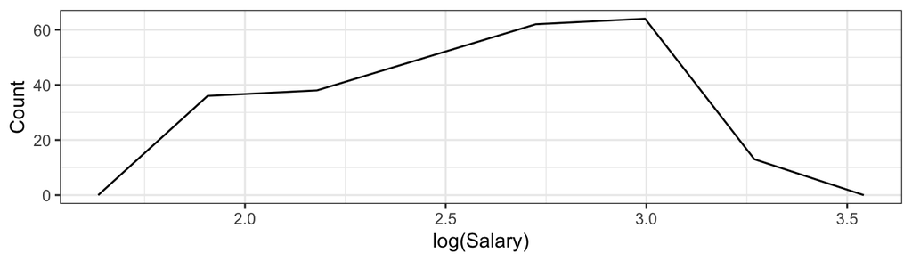

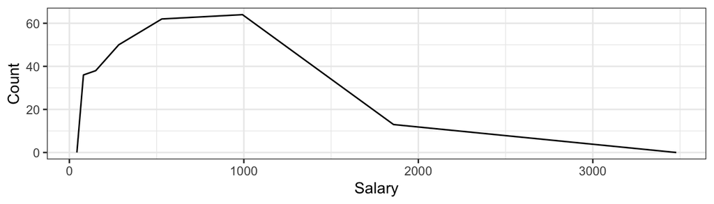

# 3 Kernel Density Estimation

Recall the definition of a density function
$$f(y) \equiv \frac{d}{dy} F(y) \equiv \lim\limits_{h \rightarrow 0} \frac{F(y + h) - F(y - h)}{2h} = \lim\limits_{h \rightarrow 0} \frac{F(y + h) - F(y)}{h},$$
where $F(x)$ is the cdf of the random variable $Y$.

What if instead, we replace $F(x + h) - F(x - h)$?

This will weight all points within $h$ of $x$ equally. A univariate *kernel density estimator* will allow a more flexible weighting scheme.

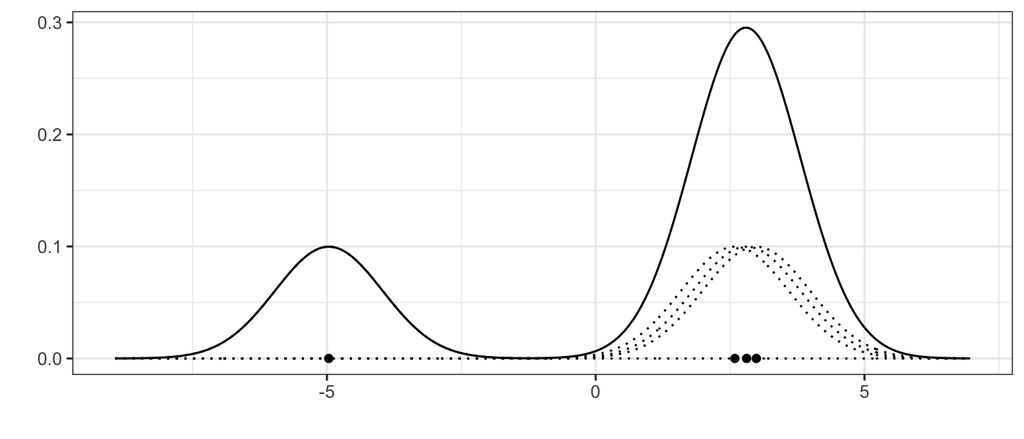

## 3.1 Choice of Bandwidth

The bandwidth parameter controls the smoothness of the density estimate.

The tradeoff that results from choosing the bandwidth + kernel can be quantified through a measure of accuracy of $\hat{f}$, such as MISE.

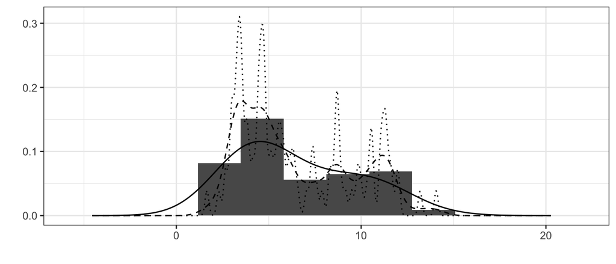

To understand bandwidth selection, let us analyze MISE. Suppose that $K$ is a symmetric, continuous probability density function with mean $0$ and variance $0 < \sigma^2_K < \infty$. Let $R(g) = \int g^2(z) dz$. Recall that

Now let $h \rightarrow 0$ and $nh \rightarrow \infty$ as $n \rightarrow \infty$.

To minimize AMISE with respect to $h$,

The term $R(f'')$ measures the roughness of the true underlying density. In general, rougher densities are more difficult to estimate and require smaller bandwidth.

The term $[\sigma_K R(K)]^{4/5}$ is a function of the kernel function $K$.

### 3.1.1 Cross Validation

### 3.1.2 Plug-in Methods

If the reference density $f$ is Gaussian and a Gaussian kernel $K$ is used,

Empirical estimation of $R(f'')$ may be a better option.

## 3.2 Choice of Kernel

There are two choices we have to make to perform density estimation:

### 3.2.1 Epanechnikov Kernel

The *Epanechnikov kernel* results from choosing $K$ to minimize $[\sigma_K R(K)]^{4/5}$, restricted to be a symmetric density with finite moments and variance equal to $1$

### 3.2.2 Canonical Kernels

Unfortunately a particular value of $h$ corresponds to a different amount of smoothing depending on which kernel is being used.

Let $h_K$ and $h_L$ denote the bandwidths that minimize AMISE when using symmetric kernel densities $K$ and $L$. Then,

Suppose we rescale a kernel shape so that $h = 1$ corresponds to a bandwidth of $\delta(K)$,

## 3.3 Bootstrapping and Variability Plot

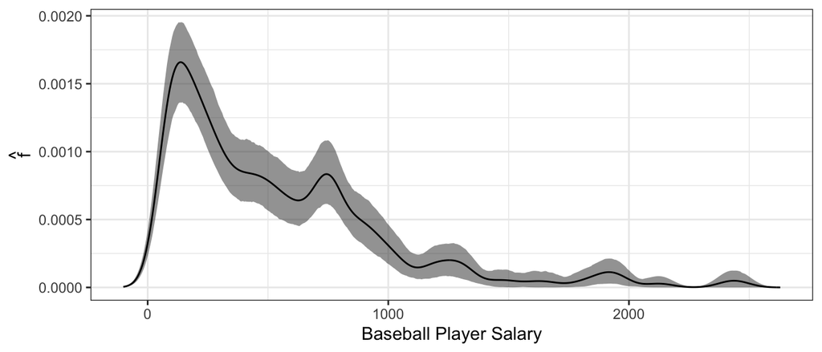